# RegressionMethods

```python
import matplotlib.pyplot as plt
import numpy as np
import tqdm
```

## Regression Methods

This notebook provides an overview of polynomial regression, logistic regression, and softmax regression.

### Polynomial Regression

Consider a set of training data $\{(x_1, y_1), ..., (x_m, y_m)\}$ with $x_i, y_i \in \mathbb{R}$ for $i \in \{1,...,m\}$. We wish to find an $n^{th}$ order polynomial $p(x) = a_0 + a_1x + a_2x^2 + ... + a_nx^n$ that best fits the data. Define the feature matrix $X \in \mathbb{R}^{(n+1) \times m}$, the coefficient vector $a \in \mathbb{R}^{n+1}$, the output vector $y \in \mathbb{R}^m$, and the error vector $\epsilon \in \mathbb{R}^m$ as shown below.

$$ \underbrace{\begin{bmatrix} 1 & x_1 & x_1^2 & ... & x_1^n \\ 1 & x_2 & x_2^2 & ... & x_2^n \\ \vdots & \vdots & \vdots & \ddots & \vdots \\ 1 & x_m & x_m^2 & ... & x_m^n \\ \end{bmatrix}}_X \underbrace{\begin{bmatrix} a_0 \\ a_1 \\ \vdots \\ a_n \end{bmatrix}}_a - \underbrace{\begin{bmatrix} \epsilon_0 \\ \epsilon_1 \\ \vdots \\ \epsilon_m \end{bmatrix}}_\epsilon = \underbrace{\begin{bmatrix} y_1 \\ y_2 \\ \vdots \\ y_m \end{bmatrix}}_y $$

We wish to find $\hat{a} \in \mathbb{R}^{n+1}$ that minimizes the cost function $J(a) = \frac{1}{2}||\epsilon||^2 = \frac{1}{2}||Xa - y||^2$.

Assuming that all of the training examples are distinct, $X$ is full-rank.

- If $n+1=m$, then the feature matrix is square and the zero-cost solution is simply $\hat{a} = X^{-1}y$.
- If $n+1<m$, then the system is overdetermined and the solution is $\hat{a} = (X^TX)^{-1} X^Ty$.
- If $n+1>m$, then the system is underdetermined and there are many solutions that all achieve zero cost. The zero-cost solution that which minimizes $||a||$ is given by $\hat{a} = X^T(XX^T)^{-1}y$.

The below code generates a noisy dataset from a 5th order polynomial, uses the least squares method to recover the coefficients, and plots the reconstructed polynomial together with the original dataset.

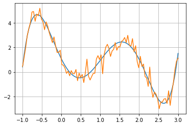

```python
def compute_polynomial(x, a):

    y = np.zeros(x.shape)
    for i, c in enumerate(a):
        y += a[i] * np.power(x, i)
    return y


def solve(x, y, n):

    np.random.seed(seed=0)
    assert n + 1 < x.size
    X = np.power(np.tile(x, (n + 1, 1)).T, range(n + 1))
    return np.linalg.inv(X.T.dot(X)).dot(X.T).dot(y)


x = np.linspace(-1, 3, 100)
noise = np.random.normal(0, 0.5, x.shape)
y = compute_polynomial(x, [1, -6, 5, 5, -5, 1]) + noise
y_inference = compute_polynomial(x, solve(x, y, 5))
plt.plot(x, y_inference)
plt.plot(x, y)
plt.grid()
plt.show()
```

### Logistic Regression

Consider a set of training data $\{(x_1, y_1), ..., (x_m, y_m)\}$ with inputs $x_i \in \mathbb{R}^n$ for $i \in \{1,...,m\}$ and outputs $y_i \in \{0, 1\}$ for $i \in \{1,...,m\}$. Logistic regression is a discriminative algorithm that seeks to learn the distribution $P(y|x)$. Specifically, the classifier is a function $f : \mathbb{R}^n \rightarrow [0, 1]$ for which $f(x) = P(y=1|x)$ and $1 - f(x) = P(y=0|x)$.

The logistic regression model has the form $f(x) = \sigma(w^Tx+ b)$ with model parameters $w \in \mathbb{R}^n$ and $b \in \mathbb{R}$ and activation function $\sigma(z) = \frac{1}{1+e^{-z}}$. We wish to find model parameters minimizing the following loss function.

$$ J(w, b) = \frac{1}{m}\sum_{i=0}^m -\left[y_i\log\left(f(x_i)\right) + (1 - y_i)\log\left(1-f(x_i)\right)\right] $$

We can train the classifier using gradient descent, given the following gradients.

$$ \delta_i = \sigma(w^Tx_i+ b) - y_i $$$$ \nabla J(w, b)_w = \frac{1}{m}\sum_{i=1}^m \delta_i x_i $$$$ \nabla J(w, b)_b = \frac{1}{m}\sum_{i=1}^m \delta_i $$

### Softmax Regression

Softmax regression is a generalization of logistic regression to cases with more than two labels. Here, the training dataset $\{(x_1, y_1), ..., (x_m, y_m)\}$ has outputs $y_i \in \{0, 1, ..., k\}$ for $i \in \{1,...,m\}$. The classifier is a function $f : \mathbb{R}^n \rightarrow [0, 1]^k$ for which $f(x)_c = P(y=c|x)$. Note that for any $x$, $f(x)$ is a probability simplex satisfying $\sum_{c=1}^k f(x)_c = 1$.

The softmax regression model has the form $f(x) = \sigma(W^Tx+ b)$ with model parameters $W \in \mathbb{R}^{k \times n}$ and $b \in \mathbb{R}^k$. The activation function is defined as follows.

$$ \sigma(z) = \frac{1}{\sum_{i=1}^k e^{z_i}} \begin{bmatrix} e^{z_1} \\ e^{z_2} \\ \vdots \\ e^{z_k} \end{bmatrix}$$

We wish to find model parameters minimizing the following loss function.

$$ J(w, b) = -\frac{1}{m}\sum_{i=0}^m \sum_{j=1}^k 1\{y_i=j\} \log\left(f(x_i)_j\right) $$

We can train the classifier using gradient descent, given the following gradients.

$$ \delta_i = \sigma(W^Tx_i+ b) - \begin{bmatrix}1\{y_i = 1\} \\ 1\{y_i = 2\} \\ \vdots \\ 1\{y_i = k\}\end{bmatrix} $$$$ \nabla J(w, b)_W = \frac{1}{m}\sum_{i=1}^m \delta_i x_i^T $$$$ \nabla J(w, b)_b = \frac{1}{m}\sum_{i=1}^m \delta_i $$

The below code generates a sample $k$-class dataset, trains softmax regression using gradient descent, and plots the resulting linear decision boundary.

```python
def softmax_fn(z):
    z -= np.max(z)
    return np.exp(z) / np.sum(np.exp(z))


def activation(W, b, x_i):
    return softmax_fn(W.dot(x_i) + b)


def one_hot(y_i, k):
    vec = np.zeros((k, 1))
    vec[int(y_i), 0] = 1
    return vec


def train_softmax(X, y, k, iters, alpha):

    W = np.random.normal(size=(k, X.shape[1]))
    b = np.random.normal(size=(k, 1))
    for epoch in tqdm.tqdm(range(iters)):
        dW = np.zeros_like(W)
        db = np.zeros_like(b)
        for i in range(X.shape[0]):
            x_i = X[i, :].reshape(-1, 1)
            delta = activation(W, b, x_i) - one_hot(y[i], k)
            dW += (1 / X.shape[0]) * delta.dot(x_i.T)
            db += (1 / X.shape[0]) * delta
        W -= alpha * dW
        b -= alpha * db
    return W, b


def generate_dataset(n_samples):
    np.random.seed(seed=0)
    m0, m1, m2 = np.array([-1, -1]), np.array([0, 1]), np.array([1, -1])
    y = np.hstack(
        (np.zeros(n_samples // 3), np.ones(n_samples // 3), 2 * np.ones(n_samples // 3))
    )
    X0 = np.random.multivariate_normal(
        m0, np.array([[0.1, 0], [0, 0.1]]), n_samples // 3
    )
    X1 = np.random.multivariate_normal(
        m1, np.array([[0.1, 0], [0, 0.1]]), n_samples // 3
    )
    X2 = np.random.multivariate_normal(
        m2, np.array([[0.1, 0], [0, 0.1]]), n_samples // 3
    )
    return np.vstack((X0, X1, X2)), y


def visualize_classifier(X, y, W, b):

    t0 = np.linspace(np.min(X[:, 0]), np.max(X[:, 0]), 100)
    t1 = np.linspace(np.min(X[:, 1]), np.max(X[:, 1]), 100)

    labels = []
    coordsx0 = []
    coordsx1 = []

    for p0 in t0:
        for p1 in t1:
            x_i = np.array([p0, p1]).reshape(-1, 1)
            labels.append(np.argmax(activation(W, b, x_i)))
            coordsx0.append(p0)
            coordsx1.append(p1)

    fig, axes = plt.subplots(nrows=1, ncols=2, figsize=(10, 4))
    axes[1].scatter(coordsx0, coordsx1, c=labels)
    axes[0].scatter(X[:, 0], X[:, 1], c=y)
    plt.show()
```

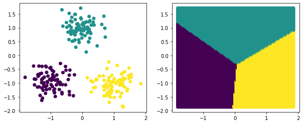

```python
X, y = generate_dataset(250)
W, b = train_softmax(X, y, 3, 100, 0.1)
visualize_classifier(X, y, W, b)
```